# Homework 3

Kaleb J. Frierson

2024-10-12

# Set-Up

Here I call libraries. This is updated throughout completion of the homework such that there is not multiple spots in the project where libraries are called.

```r
library(tidyverse)
library(p8105.datasets)
library(patchwork)
```

# Problem 1

Below I bring in the ny_noaa data from the p8105.datasets package as instructed.

```r
data("ny_noaa")
```

## Data Description

Here I determine some basic structurual information using `nrow`, `ncol`, and `colnames` functions to see row count, column count, and variables names, respectively.

```r
nrow(ny_noaa)
```

```
## [1] 2595176
```

```r
ncol(ny_noaa)
```

```
## [1] 7
```

```r
colnames(ny_noaa)
```

```
## [1] "id"   "date" "prcp" "snow" "snwd" "tmax" "tmin"
```

```r
ny_noaa
```

```
## # A tibble: 2,595,176 × 7
##    id          date        prcp  snow  snwd tmax  tmin
##    <chr>       <date>     <int> <int> <int> <chr> <chr>
##  1 US1NYAB0001 2007-11-01    NA    NA    NA <NA>  <NA>
##  2 US1NYAB0001 2007-11-02    NA    NA    NA <NA>  <NA>
##  3 US1NYAB0001 2007-11-03    NA    NA    NA <NA>  <NA>
##  4 US1NYAB0001 2007-11-04    NA    NA    NA <NA>  <NA>
##  5 US1NYAB0001 2007-11-05    NA    NA    NA <NA>  <NA>
##  6 US1NYAB0001 2007-11-06    NA    NA    NA <NA>  <NA>
##  7 US1NYAB0001 2007-11-07    NA    NA    NA <NA>  <NA>
##  8 US1NYAB0001 2007-11-08    NA    NA    NA <NA>  <NA>
##  9 US1NYAB0001 2007-11-09    NA    NA    NA <NA>  <NA>
## 10 US1NYAB0001 2007-11-10    NA    NA    NA <NA>  <NA>
## # ℹ 2,595,166 more rows
```

**There are 2595176 rows and 7 columns in this dataset. Each row appears to be a different data collection point on a given “date” from a location with a unique “id”. Measurements from these locations and times (measured as date) include data for variables called: prcp, snow, snwd, tmax, and tmin. I also view the first ten entries by running the dataset name. Of note, tmin and tmax are being treated as character variables when they should be numeric.**

Below I treat temperature as numeric.

```r
hw_df =
  ny_noaa |>
  mutate(
    tmax = as.numeric(na_if(na_if(tmax, ""), "NA")),
    tmin = as.numeric(na_if(na_if(tmin, ""), "NA"))
  )
```

Below I summarize the mean, min, and max of the maximum and minimum temperatures. `na.rm = TRUE` removes missing values from calculations.

```r
hw_df |>
  summarize(
    tmax_mean = mean(tmax, na.rm = TRUE),
    tmax_min = min(tmax, na.rm = TRUE),
    tmax_max = max(tmax, na.rm = TRUE),
    tmin_mean = mean(tmin, na.rm = TRUE),
    tmin_min = min(tmin, na.rm = TRUE),
    tmin_max = max(tmin, na.rm = TRUE)
  )
```

```
## # A tibble: 1 × 6
##   tmax_mean tmax_min tmax_max tmin_mean tmin_min tmin_max
##       <dbl>    <dbl>    <dbl>     <dbl>    <dbl>    <dbl>
## 1      140.     -389      600      30.3     -594      600
```

**Something seems odd here with the values of tmin and max. Temperatures of such extremes (high and low) seem a bit implausible. Especially in NY. Clerical error? Lets look.**

Below I make a `geom_boxplot` to view the spread of the datapoints and find any outliers.

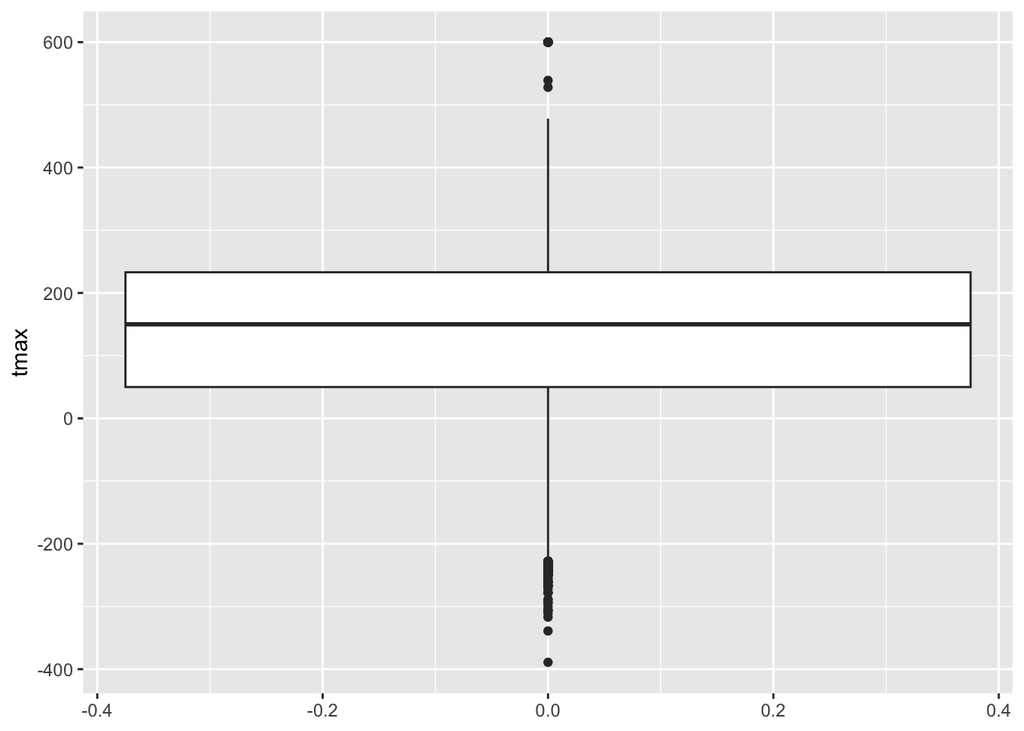

```r
hw_df |>
  ggplot(aes(y=tmax)) +
  geom_boxplot()
```

Below I will use `summarize()` to view missing across all data collection variables.

```r
hw_df |>
  summarize(
    prcp_missing = sum(is.na(prcp)),
    snow_missing = sum(is.na(snow)),
    snwd_missing = sum(is.na(snwd)),
    tmax_missing = sum(is.na(tmax)),
    tmin_missing = sum(is.na(tmin))
  )
```

```
## # A tibble: 1 × 5
##   prcp_missing snow_missing snwd_missing tmax_missing tmin_missing
##          <int>        <int>        <int>        <int>        <int>
## 1       145838       381221       591786      1134358      1134420
```

**There are over 2 million rows in this dataset. More than half of the rows have missing data. I would say this is problematic.**

## Data Cleaning

Below I drop rows with missing values, create separate variables for year, month, and day. I also convert temperature to degrees Celsius.

```r
hw_df =
  hw_df |>
  drop_na() |>
  mutate(
    year = year(date),
    month = month(date),
    day = day(date),
    tmax = tmax/10,
    tmin = tmin/10
  )

hw_df
```

```
## # A tibble: 1,222,433 × 10
##    id          date        prcp  snow  snwd  tmax  tmin  year month   day
##    <chr>       <date>     <int> <int> <int> <dbl> <dbl> <dbl> <dbl> <int>
##  1 USC00300023 1981-01-03     0     0     0 -12.2 -20.6  1981     1     3
##  2 USC00300023 1981-01-05     0     0     0  -5.6 -17.8  1981     1     5
##  3 USC00300023 1981-01-12     0     0     0 -12.2 -30.6  1981     1    12
##  4 USC00300023 1981-01-13     0     0     0  -6.7 -28.9  1981     1    13
##  5 USC00300023 1981-01-15     0     0     0  -5   -10.6  1981     1    15
##  6 USC00300023 1981-01-17     0     0     0  -1.1 -15    1981     1    17
##  7 USC00300023 1981-01-20     0     0     0   6.1  -6.7  1981     1    20
##  8 USC00300023 1981-01-21     0     0     0   1.7 -10.6  1981     1    21
##  9 USC00300023 1981-01-22     0     0     0   0.6  -5    1981     1    22
## 10 USC00300023 1981-01-23   117   127    76   2.2  -4.4  1981     1    23
## # ℹ 1,222,423 more rows
```

Below I check to see how the values for tmax and tmin look now:

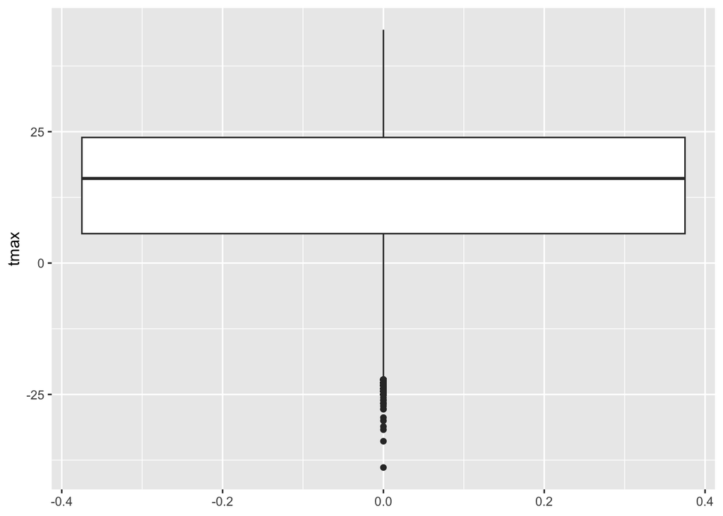

```r
hw_df |>
  ggplot(aes(y=tmax))+
  geom_boxplot()
```

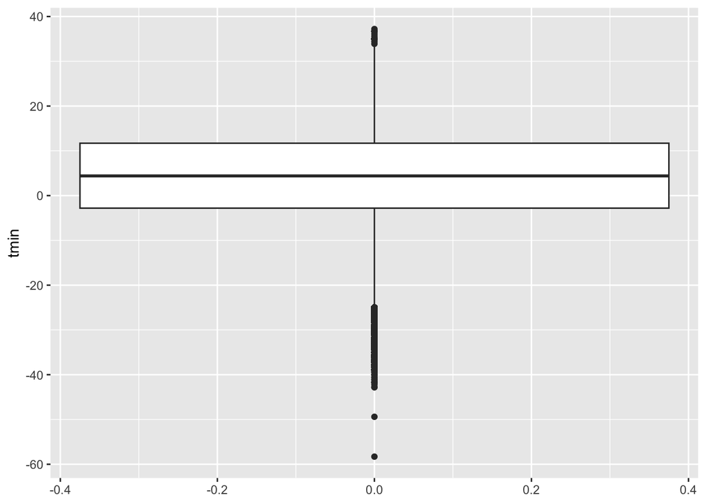

```r
hw_df|>
  ggplot(aes(y=tmin))+
  geom_boxplot()
```

**Looks a lot more sensible.**

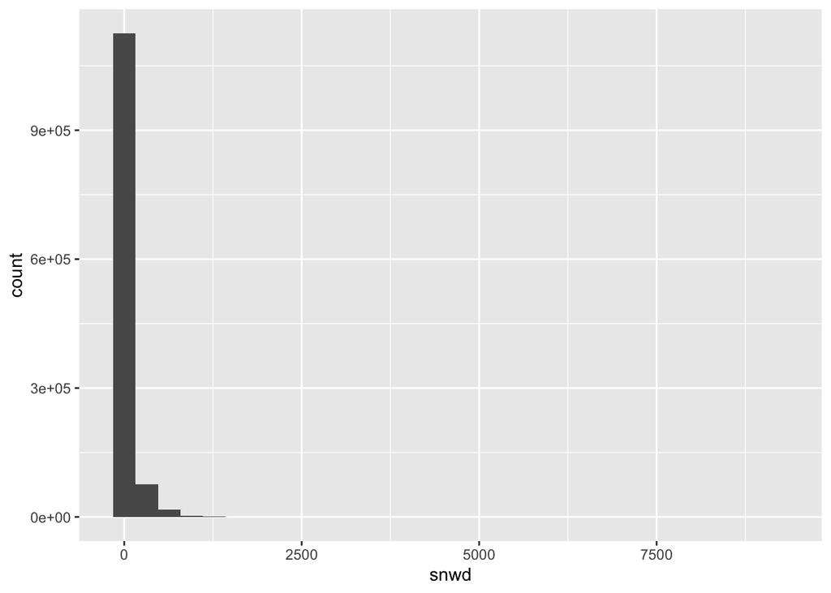

```r
hw_df |>
  ggplot(aes(x=snwd))+
  geom_histogram()
```

## Exploratory Analysis

Make a facetted plot showing the average max temperature in January and in July in each station across years. This is done below using `ggplot.` I received additional formating guidance from r-graph-gallery.com.

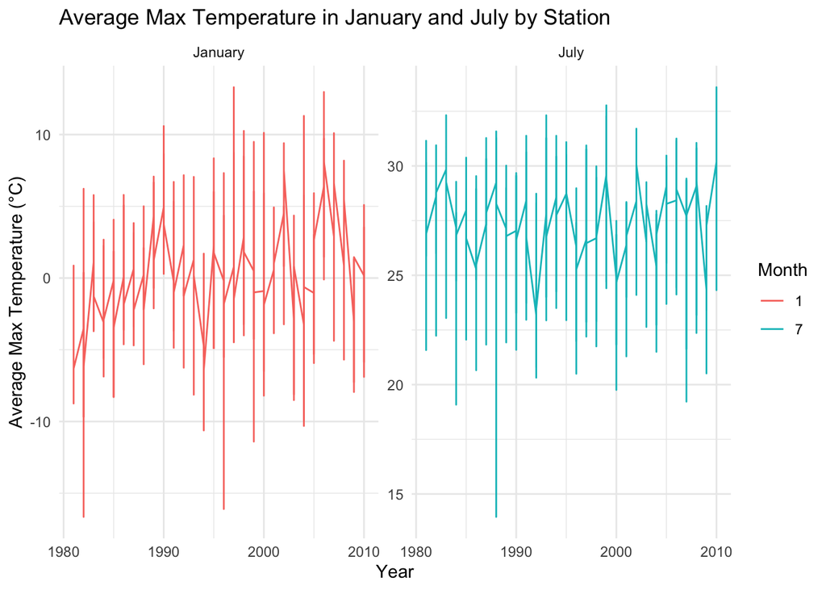

```r
avg_temp =
  hw_df |>
  filter(month %in% c(1, 7)) |>
  group_by(id, year, month) |>
  summarize(avg_tmax = mean(tmax, na.rm = TRUE), .groups = 'drop')

ggplot(avg_temp, aes(x = year, y = avg_tmax, color = factor(month))) +
  geom_line() +
  facet_wrap(
    ~ month, scales = "free_y",
    labeller = labeller(month = c(`1` = "January", `7` = "July"))) +
  labs(title = "Average Max Temperature in January and July by Station",
       x = "Year",
       y = "Average Max Temperature (°C)",
       color = "Month") +
  theme_minimal()
```

Below I use `patchwork` and `gpplot` to make a two pannel figure. See [P8105 Visualization 2](https://p8105.com/visualization_pt2.html#patchwork).

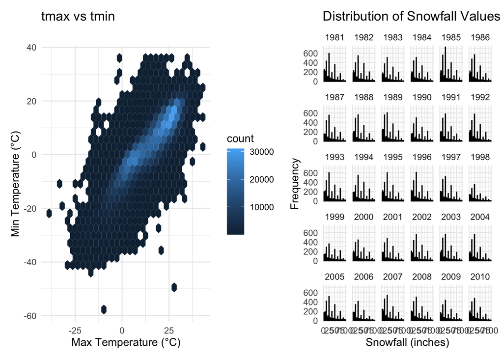

```r
t_max_t_min =
  hw_df |>
  ggplot(aes(x = tmax, y = tmin)) +
  geom_hex() +
  labs(title = "tmax vs tmin",
       x = "Max Temperature (°C)",
       y = "Min Temperature (°C)") +
  theme_minimal()

snowflake =
  hw_df |>
  filter(snow > 0 & snow < 100) |>
  ggplot(aes(x = snow)) +
  geom_histogram(binwidth = 1, fill = "blue", color = "black") +
  facet_wrap(~ year) +
  labs(title = "Distribution of Snowfall Values (0 < snow < 100)",
       x = "Snowfall (inches)",
       y = "Frequency") +
  theme_minimal()

t_max_t_min + snowflake
```

# Problem 2

## Data Wrangling

Below I use `read_csv` to bring in both datasets. I set missing value information and `col types = false` so that the information doesn’t auto populate in the rednered github document. Then I merge them. There are `250` observations in both datasets and the new dataset.

```r
mims =
  read_csv("data/mims.csv", na = c("NA", "", "."),
           show_col_types = FALSE)

dem =
  read_csv("data/dem.csv", na = c("NA", "", "."),
           skip = 4,
           show_col_types = FALSE)

merged <- full_join(dem, mims, by = "SEQN")
```

Below I `drop_na()` so there are no rows with missing values and I recode sex and education to character variables. Then I `pivot_longer()` such that each row is no longer unique to 1 SEQN, but rather each row is an entry per SEQN per minute. I `filter()` to exclude entries where age is less than 21. I also `mutate()` such that minute values are numeric, there is a variable for hour of the day, and a variable for average mims unit per hour of the day.

```r
longer =
  merged |>
  drop_na() |>
  filter(age >= 21) |>
  mutate(
    sex = recode(sex, `1` = "Male", `2` = "Female")) |>
  mutate(
    education = recode(education, `1` = "Less Than High School",
                       `2` = "High School",
                       `3` = "More Than High School")
  ) |>
  mutate(education =
           factor(education, levels = c("Less Than High School",
                                        "High School",
                                        "More Than High School"))
  ) |>
  pivot_longer(
    cols = starts_with("min"),
    names_to = "minute",
    values_to = "mims_unit"
  ) |>
  mutate(
    minute = as.numeric(gsub("min", "", minute))
  ) |>
  mutate(
    hour = ceiling(minute / 60))|>
  group_by(SEQN, hour)|>
  mutate(
    hour = ceiling(minute / 60))|>
  mutate(
    avg_hourly_mims_unit = mean(mims_unit)) |>
  group_by(SEQN, hour)
```

## Tables & Plots

Below I produce a table for the number of men and women in each education category using `knitr`.

```r
table=
  longer |>
  group_by(education, sex) |>
  summarize(count = n(), .groups = 'drop') |>
  pivot_wider(
    names_from = sex,
    values_from = count,
    values_fill = list(count = 0))


knitr::kable(table, caption = "Count of Men and Women by Education")
```

Count of Men and Women by Education

| education | Female | Male |
| --- | --- | --- |
| Less Than High School | 40320 | 38880 |
| High School | 33120 | 50400 |
| More Than High School | 84960 | 80640 |

Below I create a visualization of the age distributions for men and women in each education category.

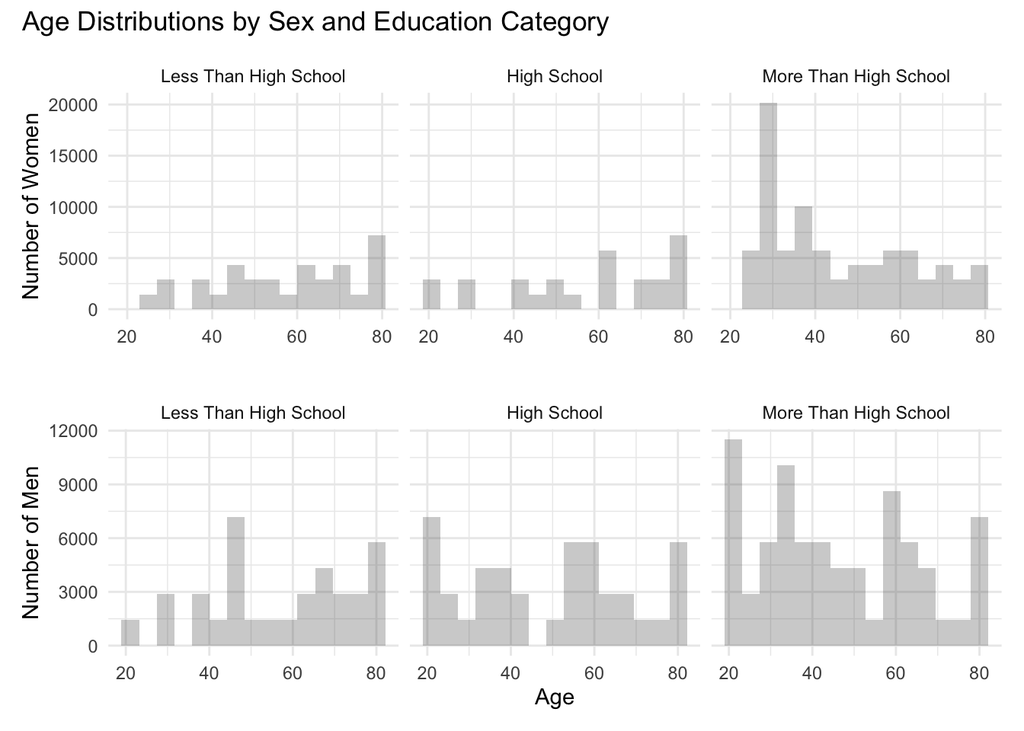

```r
men =
longer |>
  filter(sex == "Male") |>
  ggplot(aes(x = age)) +
  geom_histogram(position = "identity", alpha = 0.3, bins = 15) +
  facet_wrap(~ education) +
  labs(x = "Age",
       y = "Number of Men") +
  theme_minimal()

women =
longer |>
  filter(sex == "Female") |>
  ggplot(aes(x = age)) +
  geom_histogram(position = "identity", alpha = 0.3, bins = 15) +
  facet_wrap(~ education) +
  labs(x= "",
       y = "Number of Women") +
  theme_minimal()

combined_plot=
  women / men +
  plot_layout(guides = "collect") +
  plot_annotation(title = "Age Distributions by Sex and Education Category")

combined_plot
```

**Among study participants, there are considerably more males with high school education than female with high school education. About the same across sexes for those with less than high school and for those with more than high school (although one might say there are more women than men if you think 85000 is appreciably different from 81000, I do not).**

## Total Activity

Below I aggregate across minutes to create a total activity variable for each participant. Then I plot these total activities (y-axis) against age (x-axis). I compare men to women and have separate panels for each education level. I include a smooth to illustrate differences.

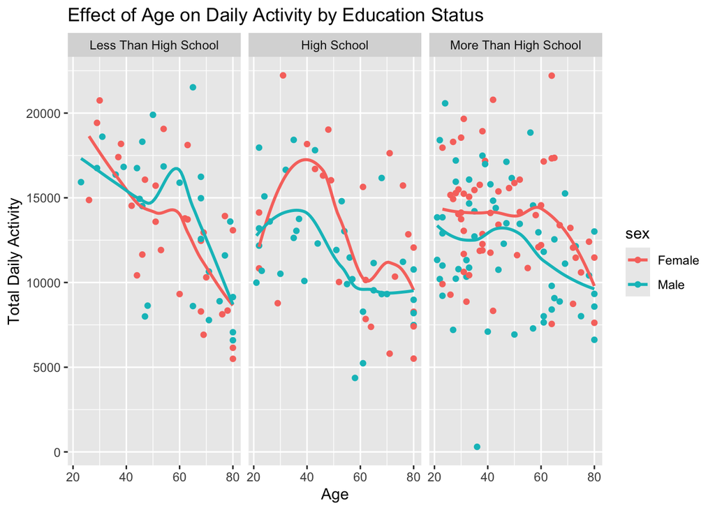

```r
total_activity =
  longer |>
  group_by(SEQN, age, sex, education) |>
  summarize(total_activity = sum(mims_unit, na.rm = TRUE),
            .groups = "drop")

total_activity |>
  ggplot(aes(x= age, y= total_activity, color = sex))+
  geom_point()+
  geom_smooth(se = FALSE)+
  facet_wrap(~education)+
  labs(x ="Age", y= "Total Daily Activity", title = "Effect of Age on Daily Activity by Education Status")
```

**Across all levels of education, daily activity decreases with age. The slope of the decease is much more noticeable across the life course with those who have less than a high school education compared to other groups. Among those who complete high school, there is a steep reduction from age 40 to 60 with a plateau for the remainder of the life course.**

Below I make a three-panel hex plot that shows the hourly measures of MIMS unit by education level and sex. The reason I chose a hex plot is because it provides a visualization of when both sexes are in a space on the graph or not.

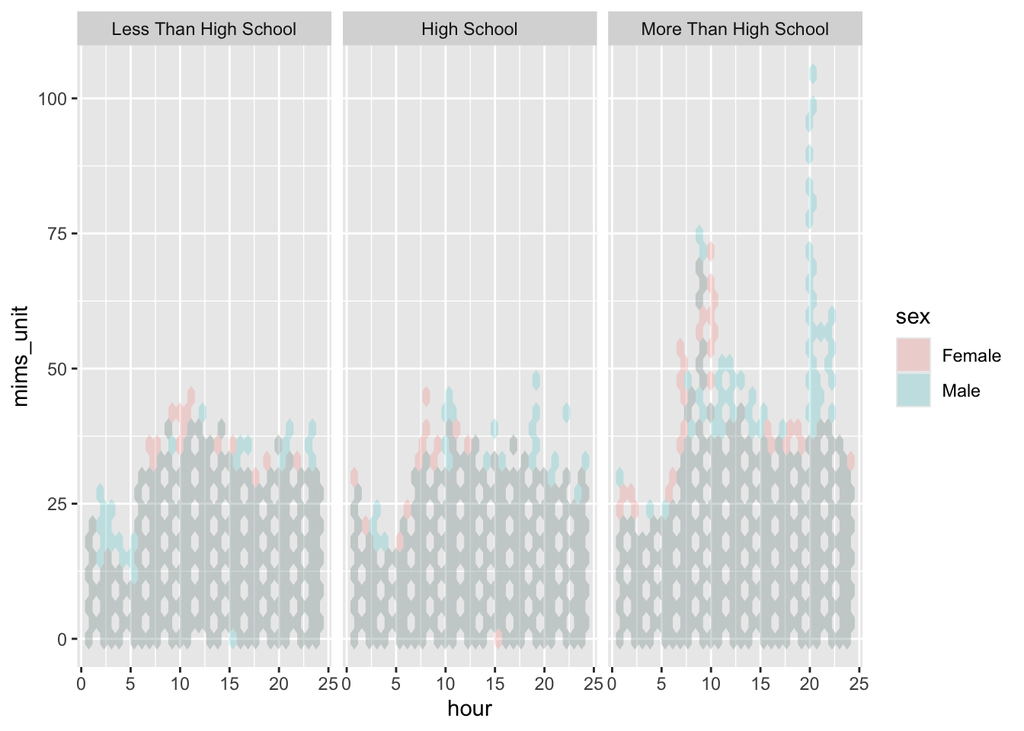

```r
longer |>
  ggplot(aes(x=hour, y=mims_unit, fill = sex))+
  geom_hex(alpha=0.2) +
  facet_wrap(~education)
```

**There seems to be more women than men active in the early morning hours among those who have more than a high school education. Additionally, in that same group, more men are active than women in the later hours of the day. I do not notice significant differences among other groups. Maybe slightly more men active after 8pm than women among those with a high school education.**

# Problem 3

## Data Wrangling

Here I use `read_csv` to import all four csv files. I use `nrow` to keep track of observations in each dataset and sum them to ensure that I have the correct number when I merge them all.

```r
jan20 =
  read_csv("data/citibike/Jan 2020 Citi.csv", show_col_types = FALSE) |>
  mutate(month = "Jan", year = 2020)
nrow(jan20)
```

```
## [1] 12420
```

```r
jan24 =
  read_csv("data/citibike/Jan 2024 Citi.csv", show_col_types = FALSE) |>
  mutate(month = "Jan", year = 2024)
nrow(jan24)
```

```
## [1] 18861
```

```r
jul20 =
  read_csv("data/citibike/July 2020 Citi.csv", show_col_types = FALSE) |>
  mutate(month = "Jul", year = 2020)
nrow(jul20)
```

```
## [1] 21048
```

```r
jul24 =
  read_csv("data/citibike/July 2024 Citi.csv", show_col_types = FALSE) |>
  mutate(month = "Jul", year = 2024)
nrow(jul24)
```

```
## [1] 47156
```

```r
12420+18861+21048+47156
```

```
## [1] 99485
```

Here I use `bind_rows` to merge all four datasets into “city” and confirm correct number of observations using `nrow`.

```r
citi =
  bind_rows(jan20, jul20, jan24, jul24)
nrow(citi)
```

```
## [1] 99485
```

## Tables

Below I create a `citi_table` dataframe that groups the city dataset by year, month, member status, assigns counts, makes a `year_month` variable (because I had made them seperate variables), pivots wider to make the table, and arranges them by the new variable.

```r
citi_table =
  citi |>
  group_by(year, month, member_casual) |>
  summarize(count = n(), .groups = 'drop') |>
  mutate(year_month = paste(month, year)) |>
  select(year_month, member_casual, count) |>
  pivot_wider(
    names_from = member_casual,
    values_from = count
  ) |>
  arrange(year_month)

citi_table
```

```
## # A tibble: 4 × 3
##   year_month casual member
##   <chr>       <int>  <int>
## 1 Jan 2020      984  11436
## 2 Jan 2024     2108  16753
## 3 Jul 2020     5637  15411
## 4 Jul 2024    10894  36262
```

Below I make a table showing the 5 most popular starting stations for July 2024 and I include the number of rides originating from these stations.

```r
popular =
  citi |>
  filter(month == "Jul", year == 2024) |>
  group_by(start_station_name) |>
  summarize(num_rides = n()) |>
  arrange(desc(num_rides)) |>
  head(5)

popular
```

```
## # A tibble: 5 × 2
##   start_station_name       num_rides
##   <chr>                        <int>
## 1 Pier 61 at Chelsea Piers       163
## 2 University Pl & E 14 St        155
## 3 W 21 St & 6 Ave                152
## 4 West St & Chambers St          150
## 5 W 31 St & 7 Ave                146
```

## Plots

Below I make a plot to investigate the effects of day of the week, month, and year on median ride duration. This plot includes panels using`facet_wrap`. Help in formatting from r-graph-gallery.com.

```r
ride_summary =
  citi |>
  group_by(weekdays, month, year) |>
  summarize(median_duration = median(duration, na.rm = TRUE)) |>
  ungroup()
```

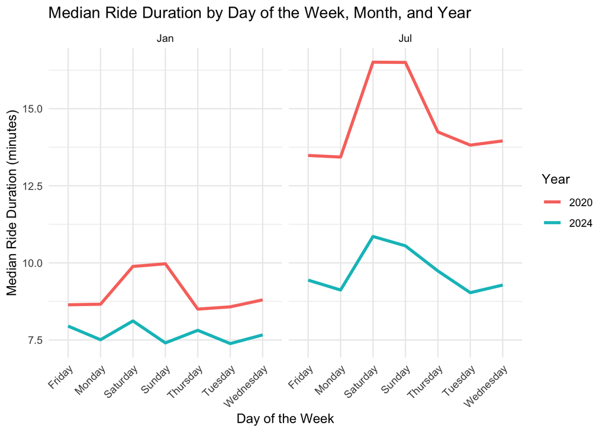

```r
ride_summary |>
  ggplot(aes(x= weekdays, y = median_duration, color = as.factor(year))) +
  geom_line(size = 1.2, aes(group = interaction(year, month))) +
  facet_wrap(~month) +
  labs(
    title = "Median Ride Duration by Day of the Week, Month, and Year",
    x = "Day of the Week",
    y = "Median Ride Duration (minutes)",
    color = "Year"
  ) +
  theme_minimal() +
  theme(axis.text.x = element_text(angle = 45, hjust = 1))
```

Below I use data in 2024 to make a figure that shows the impact of month, membership status, and bike type on the distribution of ride duration. I chose to use boxplots across each different group.

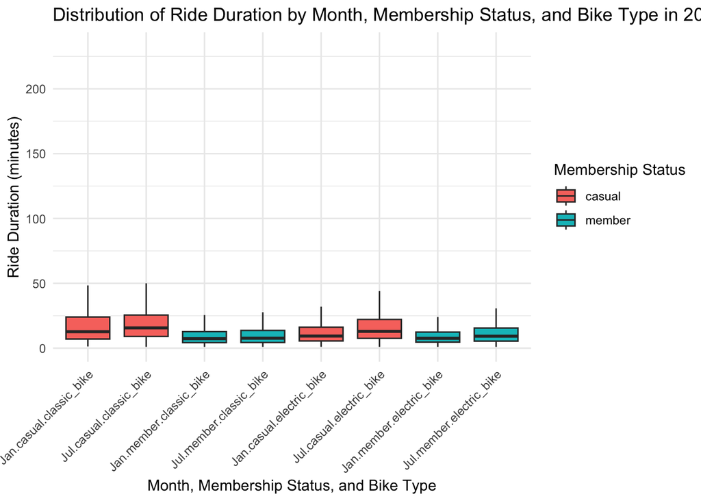

```r
citi_2024 =
  citi |>
  filter(year == 2024)

citi_2024 |>
  ggplot(aes(
    x = interaction(month, member_casual, rideable_type),
    y = duration)) +
  geom_boxplot(aes(fill = member_casual), outlier.colour = NA,
               position = position_dodge(0.8)) +
  labs(
    title = "Distribution of Ride Duration by Month, Membership Status, and Bike Type in 2024",
    x = "Month, Membership Status, and Bike Type",
    y = "Ride Duration (minutes)",
    fill = "Membership Status"
  ) +
  theme_minimal() +
  theme(axis.text.x = element_text(angle = 45, hjust = 1))
```